# Basic concepts for differential abundance analysis of proteomics data

## 7.4 True positive - False Discovery Proportion plots

We generate the TPR-FDP curves to assess the performance of the different workflows to prioritise differentially abundant proteins. Again, these curves are built using the ground truth information about which proteins are differentially abundant (spiked in) and which proteins are constant across samples.

**Implementation details**

We create two functions to compute the TPR and the FDP.

```r
computeFDP <- function(pval, tp) {
    ord <- order(pval)
    fdp <- cumsum(!tp[ord]) / 1:length(tp)
    fdp[order(ord)]
}
computeTPR <- function(pval, tp, nTP = NULL) {
    if (is.null(nTP)) nTP <- sum(tp)
    ord <- order(pval)
    tpr <- cumsum(tp[ord]) / nTP
    tpr[order(ord)]
}
```

We apply these functions and compute the corresponding metric using the statistical inference results and the ground truth information.

```r
performance <- inferences |>
  group_by(contrast) |>
    na.exclude() |>
    mutate(tpr = computeTPR(pval, spikein == "ups"),
           fdp = computeFDP(pval, spikein == "ups")) |>
    arrange(fdp)
```

We also highlight the observed FDP at a $alpha = 5\%$ FDR threshold.

```r
workPoints <- performance |>
  group_by(contrast) |>
    filter(adjPval < alpha) |>
    slice_max(pval)
```

```r
pTprFdp <- ggplot(performance) +
    aes(
        y = fdp,
        x = tpr,
    ) +
    geom_line() +
    geom_point(data = workPoints, size = 3) +
    geom_hline(yintercept = 0.05, linetype = 2) +
    facet_wrap( ~ contrast) +
    coord_flip(ylim = c(0, 0.2)) +
    theme_minimal()
```

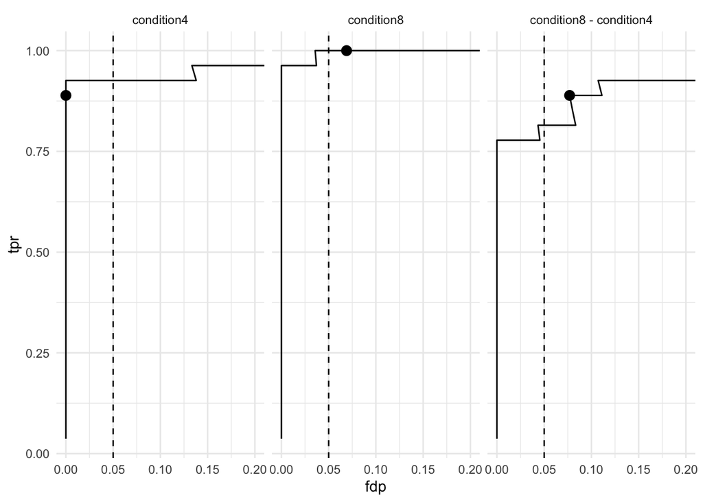

```r
pTprFdp
```

## References

Staes, An, Teresa Mendes Maia, Sara Dufour, et al. 2024. “Benefit of in Silico Predicted Spectral Libraries in Data‑independent Acquisition Data Analysis Workflows.” *Journal of Proteome Research* 23 (6): 2078–89. https://doi.org/10.1021/acs.jproteome.4c00048.

## Footnotes

[^1]: The ion selection for MS2 depends on the data recorded in MS1. Therefore, this approach is referred to as data dependent acquisition (DDA).
[^2]: MaxQuant also computes a protein table. However, we found that starting from MaxQuant’s protein table leads to a decrease in performance. We will illustrate in this tutorial how to build the protein table.
[^3]: Improving peptide identification is outside the scope of this tutorial
[^4]: A `QFeatures` object can be seen as a special list of `SummarizedExperiment` objects.
[^5]: see also the [R for mass spectrometry book](https://rformassspectrometry.github.io/book/sec-quant.html)
[^6]: We will explain this with more details at the end of the summarisation step
[^7]: In fact, this is also true for the previous transformation where the precursors are linked across sets.
[^8]: Note that we have the spike-in concentration encoded in two ways. `ratio` is encoded as a numerical value and provides the actual ratio for UPS on 10 for yeast. `condition` is encoded as a factor, meaning that every concentration is regarded as an independent group. We will use the latter encoding as most common research questions consist of group-wise comparisons. The modelling of concentration as a numeric will be discussed in a dedicated section
[^9]: Categorical variables are encoded using dummy coding.
[^10]: We don’t need to specify the intercept as R automatically adds it during model estimation. you can explicitly add it using `~ 1 + ...`, you can also suppress it using `~ 0 +`. When an intercept is included, one of the groups is defined as the reference group and its corresponding model parameter is absorbed in the intercept. The residuals don’t need to be specified as they are part of the model estimation process.
[^11]: Note, that we only need to specify the names of the model parameters that are involved in the contrast when using the make contrast function. The hypothesisTest function below will then subset the relevant part from the model output. Also, note that the contrast matrix in this example is trivial. However, we will later show how to asses multiple hypotheses at once and then the contrast matrix consists of multiple columns, with one column for each contrast
[^12]: Note, that upon this transformation a value of 1 represents a p-value of 0.1, 2 a p-value of 0.01, 3 a p-value of 0.001, etc.
[^13]: The `scales()` function aligns the means and the centered standard deviations by column. Since we want to scale by row, we need to transpose (`t())`) before scaling and transpose back after scaling. Scaling the data will remove changes in feature intensities that are caused by uninteresting changes in ionisation efficiency.